# concept_3_3

## ECON 0150 | Economic Data Analysis

Building economic models with data.

### *Part 3.3 | Quantifying Uncertainty*

## New Jersey Minimum Wage Study

The simplest economic model predicts employment should **fall**.

- NJ raised its minimum wage in 1992.
- Card and Krueger measured how 331 NJ restaurants’ employment changed.
- Employment increased by **0.59 FTE workers** per store on average.
- This is the **sample mean** ($\bar{x}$) from $n=331$ restaurants.

## New Jersey Minimum Wage Study

The simplest economic model predicts employment should **fall**.

**Question.** How do we learn about the population mean ($\mu$) if all we observe is $\bar{x} = 0.59$ FTE?

## Central Limit Theorem: Refresher

The sample mean follows a normal distribution around the true mean ($\mu$).

As the sample size grows, the distribution of $\bar{x}$ converges to a normal distribution centered on $\mu$ with standard deviation $SE = \sigma / \sqrt{n}$.

$$\bar{x} \xrightarrow{d} N\Big(\mu, \frac{\sigma}{\sqrt{n}}\Big)$$

- We don’t need to know the shape of the distribution to know the shape of the sampling distribution.
- The sampling distribution (what we draw our sample mean from) is centered on the population mean.
- The variability in sample means gets smaller as the sample size grows.

## Confidence Intervals: Known $\mu$ and $\sigma$

We can calculate all kinds of probability if we know just $\mu=0$ and $\sigma = 9.8$.

**Question**. With $n=331$, what’s the probability $\bar{x}$ is within $2 \times SE$ of $\mu$?

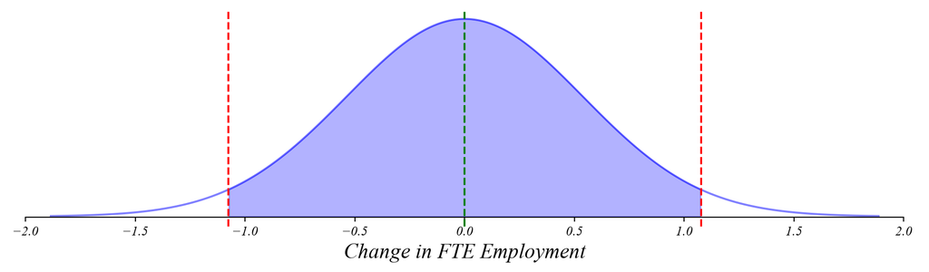

*> $P(\mu - 2 \times SE \leq \bar{x} \leq \mu + 2 \times SE) \approx 0.95$*

This interval will contain 95% of our sample means.

## Exercise 3.3 | Confidence Intervals: Known $\mu$ & $\sigma$

$\sigma = 9.8$ and $n=331$

**Question:** what’s the probability $\bar{x}$ is closer than $1 \times SE$ to $\mu$?

```python
se = sigma / np.sqrt(n)
stats.norm.cdf(mu + 1*se, loc=mu, scale=se) - stats.norm.cdf(mu - 1*se, loc=mu, scale=se)
```

## Confidence Intervals are About Probability

100 samples, each with $\pm SE$ CI centered on $\mu$.

Each dot is a sample mean $\bar{x}$ from a different sample.

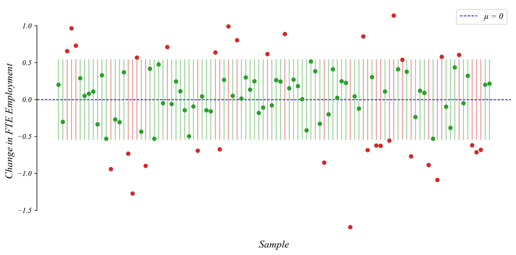

*> the confidence interval around $\mu$ contains most but not all sample means $\bar{x}$*

*> about 68 out of 100 intervals capture the truth*

## Exercise 3.3 | Simulating Confidence Intervals

Simulate employment changes and calculate the 68% confidence interval.

Generate some sample data.

```python
sample = np.random.normal(0, 9.8, 331)
```

Calculate sample statistics.

```python
x_bar = np.mean(sample)
mu = 0
se = 9.8 / np.sqrt(331)
mu - se, mu + se
```

```
(np.float64(-0.5386567157307265), np.float64(0.5386567157307265))
```

*> if we took many samples, 68% of the time $\bar{x}$ would land inside this interval*

## The Problem

We centered the confidence interval on $\mu$. **But we don’t *know* $\mu$**.

- If we knew the true effect of the minimum wage, we wouldn’t need the data
- So how is a confidence interval centered on $\mu$ useful?

## The Centerpoint Flip

The distance between $\bar{x}$ and $\mu$ is the same in both directions.

If $\bar{x}$ is within $1\times SE$ of $\mu$, then $\mu$ is within $1\times SE$ of $\bar{x}$.

*> instead of asking where $\bar{x}$ lands relative to $\mu$…*

*> we ask where $\mu$ could be relative to our observed $\bar{x}$*

## The Centerpoint Flip

The distance between $\bar{x}$ and $\mu$ is the same in both directions..

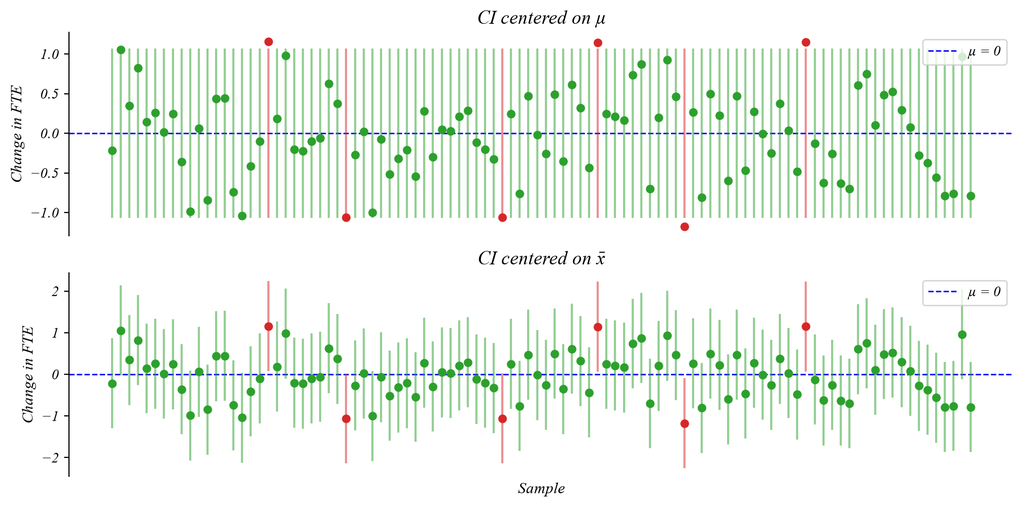

*> if $\bar{x}$ is in the $CI$ centered on $\mu$, then $\mu$ is in the $CI$ centered on $\bar{x}$*

## New Jersey: 95% Confidence Interval

Card and Krueger observed $\bar{x} = 0.59$ from one sample of 331 restaurants.

They drew one sample and centered the CI on $\bar{x}$:

$$\bar{x} \pm 2 \times SE$$

$$= 0.59 \pm 2 \times 0.54$$

$$= [-0.49, \; 1.67]$$

**Question.** Is $\mu$ inside our interval?

## Confidence Intervals: Interpretation

Is $\mu$ inside our interval?

Our study is one of these bars. Which one is it?

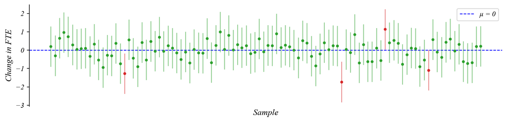

Our interval either contains $\mu$ or it doesn’t. We don’t know which.

Our “95% confidence” means that **the method works 95% of the time**, not that *this* interval has a 95% chance of containing $\mu$.

## Confidence Intervals: Interpretation

Is $\mu$ inside our interval?

Our study is one of these bars. Which one is it?

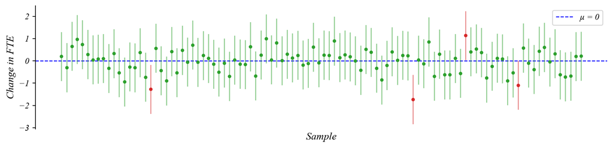

Our interval either contains $\mu$ or it doesn’t. We don’t know which.

*Our confidence is in the method, not the specifc interval we estimated!*

## Confidence Intervals: Unknown $\sigma$

What if we don’t know $\sigma$ either?

- We used $\bar{x}$ to estimate $\mu$. Can we use $S$ to estimate $\sigma$?
- Yes, but $S$ is itself a random variable, varying from sample to sample.
- Replacing $\sigma$ with $S$ introduces a new source of uncertainty.

## Sampling Variability: $S$

What if Card and Krueger had only surveyed 15 restaurants?

How close would $S$ be to $\sigma$ with only 15 restaurants? Let’s draw 1,000 samples.

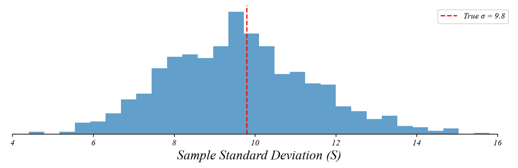

Like $\bar{x}$ is distributed around $\mu$, $S$ is distributed around $\sigma$.

## The t-Distribution

…accounts for the extra uncertainty in $S$ around $\sigma$.

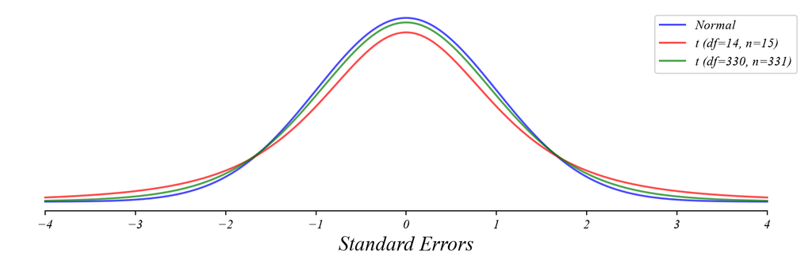

- The t-Dist accounts for the extra uncertainty when we use $S$ instead of $\sigma$.
- When $n$ is large, $S$ is close to $\sigma$ and the t-Dist approaches Normal.

## Putting It All Together

Now we can quantify our uncertainty about the true employment effect.

1. **Center** the sampling distribution on $\bar{x} = 0.59$.
2. **Width** comes from $S / \sqrt{n}$, the sample standard error.
3. **Shape** is the t-distribution with $n - 1$ degrees of freedom.

**The Card and Krueger** ($\bar{x} = 0.59$, $S \approx 9.8$, $n = 331$):

$$95\% \text{ CI}: \quad 0.59 \pm 1.967 \times 0.54 = [-0.47, \; 1.65]$$

## Testing the Theory

From estimating a range for $\mu$ to testing a specific claim about $\mu$.

- Economic theory predicts employment should fall (or at least not change).
- Card and Krueger observed $\bar{x} = +0.59$. Is that consistent with no effect?
- Instead of asking where $\mu$ might be, we test a specific value: $\mu = 0$.

## The Null Hypothesis

We formalize this approach by setting up a “null hypothesis”

**Null Hypothesis** ($H_0$): *The minimum wage had no effect on employment*

- $H_0: \mu = 0$

**Testing Question**:

- How “surprising” is our data if $H_0$ were true?

## NJ Employment Change

Where does our sample fall on the null distribution?

If $\mu = 0$, the sampling distribution of $\bar{x}$ is centered on 0.

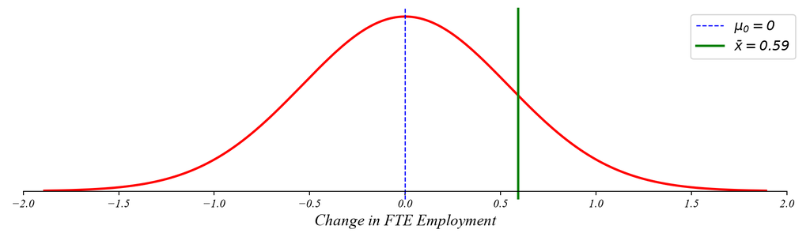

**Questions.** Is 0.59 far from 0? How would we know?

## Quantifying Surprise: The p-value

What proportion of the null distribution is *at least as extreme* as our sample?

If $\mu = 0$, the sampling distribution of $\bar{x}$ is centered on 0.

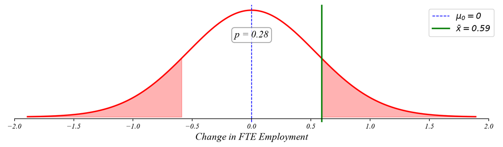

The shaded area is the probability of getting a result as extreme as ours, if $\mu = 0$.

$p = 0.28$: about 28% of samples would look this extreme or more.

## The t-Statistic

How many standard errors is our sample mean from the null?

The **t-statistic** measures how many standard errors our sample mean is from the null value:

$$t = \frac{\bar{x} - \mu_0}{S/\sqrt{n}}$$

$$t = \frac{0.59 - 0}{9.8/\sqrt{331}} = \frac{0.59}{0.54} = 1.09$$

Where:

- $\bar{x}$ is our sample mean (0.59 FTE)
- $\mu_0$ is our null value (0)
- $S$ is our sample standard deviation (9.8)
- $n$ is our sample size (331)

## Statistical vs. Practical Significance

A caution about hypothesis testing

**Statistical significance:**

- Formal rejection of the null hypothesis (p < 0.05)
- Only tells us if the effect is unlikely to be exactly zero

**Practical significance:**

- Whether the effect size matters in the real world
- Card and Krueger: the *direction* contradicted theory, even though NJ alone wasn’t significant

*> always consider the magnitude of the effect, not just the p-value*

## Looking Ahead

The hypothesis testing framework is powerful and general.

- Part 3.4 | **The Simplest Linear Model**
- Part 4 | **Bivariate Models**

*> the tools we built today apply to every model we’ll see in Parts 4 and 5*